# Module 3: Peer Reviewed Assignment

### Outline:

The objectives for this assignment:

1. Learn how to read and interpret p-values for coefficients in R.
2. Apply Partial F-tests to compare different models.
3. Compute confidence intervals for model coefficients.
4. Understand model significance using the Overall F-test.
5. Observe the variability of coefficients using the simulated data.

General tips:

1. Read the questions carefully to understand what is being asked.
2. This work will be reviewed by another human, so make sure that you are clear and concise in what your explanations and answers.

```python
# Load Required Packages
library(ggplot2)
```

## Problem 1: Individual t-tests

The dataset below measures the chewiness (mJ) of different berries along with their sugar equivalent and salt (NaCl) concentration. Let's use these data to create a model to finally understand chewiness.

Here are the variables:

1. `nacl`: salt concentration (NaCl)
2. `sugar`: sugar equivalent
3. `chewiness`: chewiness (mJ)

Dataset Source: I. Zouid, R. Siret, F. Jourjion, E. Mehinagic, L. Rolle (2013). "Impact of Grapes Heterogeneity According to Sugar Level on Both Physical and Mechanical Berries Properties and their Anthocyanins Extractability at Harvest," Journal of Texture Studies, Vol. 44, pp. 95-103.

#### 1. (a) Simple linear regression (SLR) parameters

In the below code, we load in the data and fit a SLR model to it, using `chewiness` as the response and `sugar` as the predictor. The summary of the model is printed. Let $\alpha = 0.05$.

Look at the results and answer the following questions:

- What is the hypothesis test related to the p-value `2.95e-09`? Clearly state the null and alternative hypotheses and the decision made based on the p-value.
- Does this mean the coefficient is statistically significant?
- What does it mean for a coefficient to be statistically significant?

```python
# Load the data
chew.data = read.csv("berry_sugar_chewy.csv")

chew.lmod = lm(chewiness~sugar, data=chew.data)
summary(chew.lmod)
```

```
Call:
lm(formula = chewiness ~ sugar, data = chew.data)

Residuals:
    Min      1Q  Median      3Q     Max
-2.4557 -0.5604  0.1045  0.5249  1.9559

Coefficients:
             Estimate Std. Error t value Pr(>|t|)
(Intercept)  7.662878   0.756610  10.128  < 2e-16 ***
sugar       -0.022797   0.003453  -6.603 2.95e-09 ***
---
Signif. codes:  0 ‘***’ 0.001 ‘**’ 0.01 ‘*’ 0.05 ‘.’ 0.1 ‘ ’ 1

Residual standard error: 0.9178 on 88 degrees of freedom
Multiple R-squared:  0.3313,	Adjusted R-squared:  0.3237
F-statistic: 43.59 on 1 and 88 DF,  p-value: 2.951e-09
```

- The null hypothesis is $H_0$: $\beta_{sugar} = 0$ and the alternative hypothesis is $H_1$: $\beta_{sugar} \neq 0$. Since the p-value from the t-test is less than our pre-selected level of $\alpha = 0.05$, we may reject the null hypothesis that the true parameter value of $\beta_{sugar}$ is 0.
- Yes, the coefficient is considered statistically significant because the null hypothesis was rejected due to the p-value being less than 0.05.
- If the coefficient is statistically significant, that means there is statistical evidence that keeping the coefficient in the model will produce a better model than excluding the coefficient.

#### 1. (b) MLR parameters

Now let's see if the second predictor/feature `nacl` is worth adding to the model. In the code below, we create a second linear model fitting `chewiness` as the response with `sugar` and `nacl` as predictors.

Look at the results and answer the following questions:

- Which, if any, of the slope parameters are statistically significant?
- Did the statistical significance of the parameter for `sugar` stay the same, when compared to 1 (a)? If the statistical signficance changed, explain why it changed. If it didn't change, explain why it didn't change.

```python
chew.lmod.2 = lm(chewiness ~ ., data=chew.data)
summary(chew.lmod.2)

cor(chew.data$nacl, chew.data$sugar)
```

```
Call:
lm(formula = chewiness ~ ., data = chew.data)

Residuals:
    Min      1Q  Median      3Q     Max
-2.3820 -0.6333  0.1234  0.5231  1.9731

Coefficients:
            Estimate Std. Error t value Pr(>|t|)
(Intercept)  -7.1107    13.6459  -0.521    0.604
nacl          0.6555     0.6045   1.084    0.281
sugar        -0.4223     0.3685  -1.146    0.255

Residual standard error: 0.9169 on 87 degrees of freedom
Multiple R-squared:  0.3402,	Adjusted R-squared:  0.325
F-statistic: 22.43 on 2 and 87 DF,  p-value: 1.395e-08
```

0.999956186017247

- Neither of the slope parameters are statistically significant because their p-values are both larger than the $\alpha$ level 0.05.
- Adding the nacl predictor to the model caused the sugar predictor to lose its statistical significance. To figure out why, we can simply examine the correlation between `sugar` and `nacl` and see that it is practically 1. Since the `sugar` and `nacl` predictor are suffering from multicollinearity, the calculations for individual predictors can be subject to erratic changes in the coefficient estimates and t-test p-value results.

#### 1. (c) Model Selection

Determine which of the two models we should use. Explain how you arrived at your conclusion and write out the actual equation for your selected model.

```python
anova(chew.lmod)
anova(chew.lmod.2)
anova(chew.lmod, chew.lmod.2)
```

A anova: 2 × 5

|  | Df <int> | Sum Sq <dbl> | Mean Sq <dbl> | F value <dbl> | Pr(>F) <dbl> |
| --- | --- | --- | --- | --- | --- |
| sugar | 1 | 36.72084 | 36.7208401 | 43.59357 | 2.951385e-09 |
| Residuals | 88 | 74.12640 | 0.8423454 | NA | NA |

A anova: 3 × 5

|  | Df <int> | Sum Sq <dbl> | Mean Sq <dbl> | F value <dbl> | Pr(>F) <dbl> |
| --- | --- | --- | --- | --- | --- |
| nacl | 1 | 36.604925 | 36.6049249 | 43.542729 | 3.118390e-09 |
| sugar | 1 | 1.104303 | 1.1043034 | 1.313604 | 2.548858e-01 |
| Residuals | 87 | 73.138008 | 0.8406668 | NA | NA |

A anova: 2 × 6

|  | Res.Df <dbl> | RSS <dbl> | Df <dbl> | Sum of Sq <dbl> | F <dbl> | Pr(>F) <dbl> |
| --- | --- | --- | --- | --- | --- | --- |
| 1 | 88 | 74.12640 | NA | NA | NA | NA |
| 2 | 87 | 73.13801 | 1 | 0.9883882 | 1.175719 | 0.2812249 |

We should select `chew.lmod` because there is a statistically significant predictor, `sugar`, in that model. The other model has no significant predictors because of the multicollinearity between `sugar` and `nacl`. Next, the intercept for the two predictor model is negative; one would not expect a grape to have a negative amount of chewiness so that model fails pragmatically. Furthermore, by examining the F-statistic values for each model, we can see that the single predictor model has a higher F-statistic and a lower p-value.

`chewiness` = 7.662878 + (-0.022797 * `sugar`)

#### 1. (d) Parameter Confidence Intervals

Compute $95\%$ confidence intervals for each parameter in your selected model. Then, in words, state what these confidence intervals mean.

```python
sugar_interval <- confint(chew.lmod, level = 0.95)
sugar_interval
```

A matrix: 2 × 2 of type dbl

|  | 2.5 % | 97.5 % |
| --- | --- | --- |
| (Intercept) | 6.15927388 | 9.16648152 |
| sugar | -0.02965862 | -0.01593536 |

The confidence interval for the `sugar` parameter represents values for the population parameter for which the parameter and its estimate are not statistically significant in their difference at the 5% level. Another way to think about the meaning of the confidence interval is that for repeated sampling, the percentage of calculated confidence intervals which contained the true population parameter for `sugar` would tend towards 95%.

Similarly, the confidence interval for the intercept parameter represents the same concept but for the $\beta_0$ parameter instead of the $\beta_{sugar}$ parameter.

# Problem 2: Variability of Slope in SLR

In this exercise we'll look at the variability of slopes of simple linear regression models fitted to realizations of simulated data.

Write a function, called `sim_data()`, that returns a simulated sample of size $n = 20$ from the model $Y = 1 + 2.5X + \epsilon$ where $\epsilon \overset{iid}{\sim} N(0, 1)$. We will then use this generative funciton to understand how fitted slopes can vary, even for the same underlying population.

```python
sim_data <- function(n=20, var=1, beta.0=1, beta.1=2.5){
    # BEGIN SOLUTION HERE
    x = seq(-1, 1, length.out = n); beta0 = 1; beta1 = 2.5; e = rnorm(n, 0, sqrt(var))
    y = beta0 + beta1*x + e
    # END SOLUTION HERE
    data = data.frame(x=x, y=y)
    return(data)
}
```

#### 2. (a) Fit a slope

Execute the following code to generate 20 data points, fit a simple linear regression model and plot the results.

Just based on this plot, how well does our linear model fit the data?

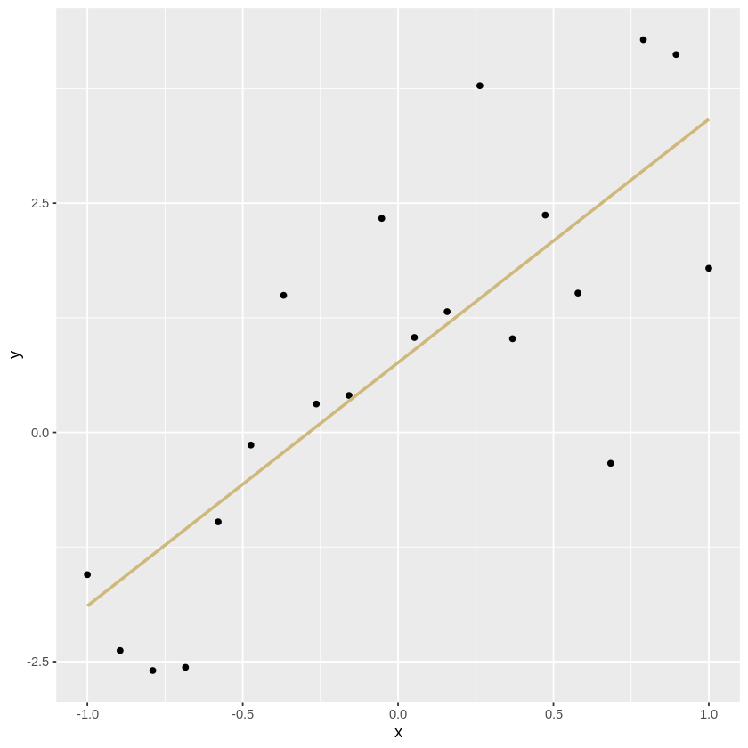

```python
data = sim_data()
lmod = lm(y~x, data=data)
#summary(lmod)
ggplot(aes(x=x, y=y), data=data) +
    geom_point() +
    geom_smooth(method="lm", formula=y~x, se=FALSE, color="#CFB87C")
```

The data appears to have a moderate positive linear correlation, just from visually examining the plot. The residuals aren't very tight about the line of best fit but the data clearly appear linear by nature.

#### 2. (b) Do the slopes change?

Now we want to see how the slope of our line varies with different random samples of data. Call our data genaration funciton $50$ times to gather $50$ independent samples. Then we can fit a SLR model to each of those samples and plot the resulting slope. The function below performs this for us.

Experiment with different variances and report on what effect that has to the spread of the slopes.

```python
gen_slopes <- function(num.slopes=50, var=1, num.samples=20){
    g = ggplot()
    # Repeat the sample for the number of slopes
    for(ii in 1:num.slopes){
        # Generate a random sampling of data
        data = sim_data(n=num.samples, var=var)
        # Add the slope of the best fit linear model to the plot
        g = g + stat_smooth(aes(x=x, y=y), data=data, method="lm", geom="line",
                            se=FALSE, alpha=0.4, color="#CFB87C", size=1)
    }
    return(g)
}
```

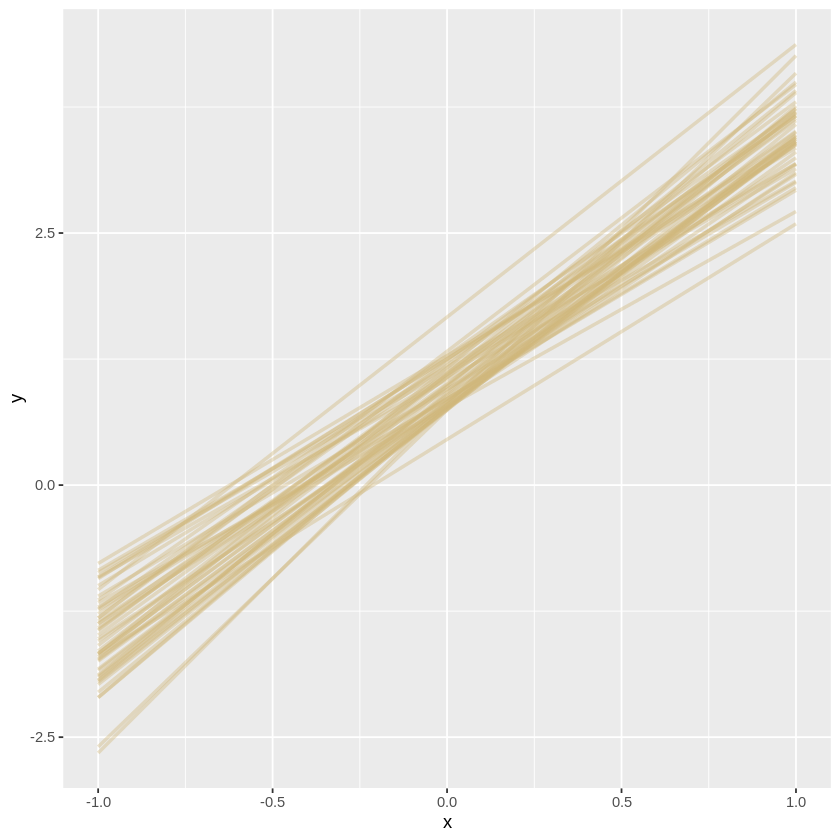

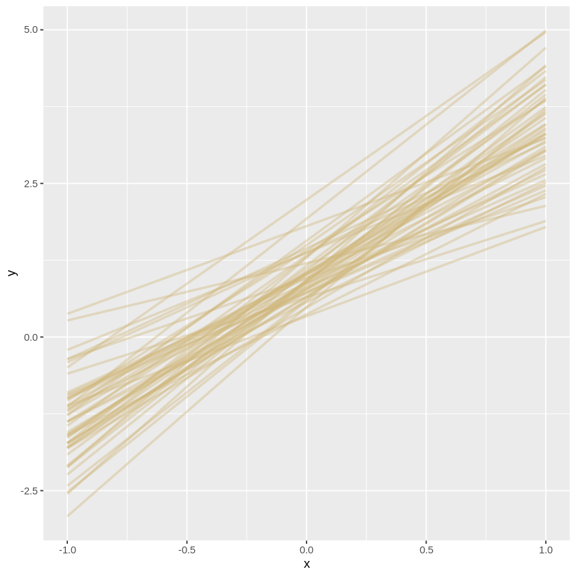

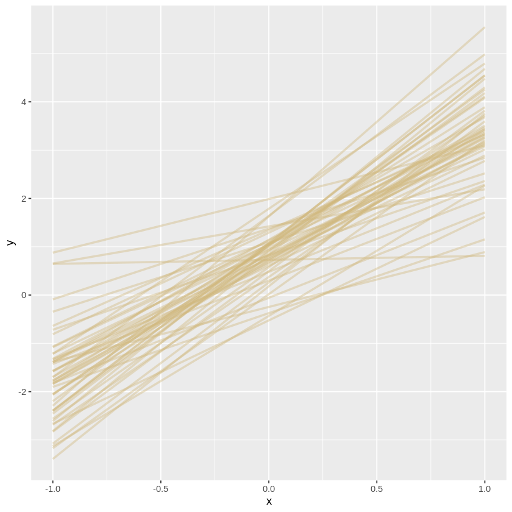

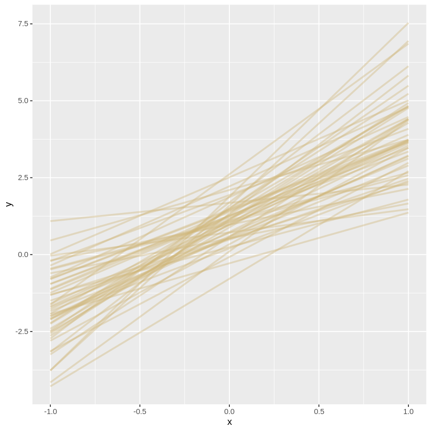

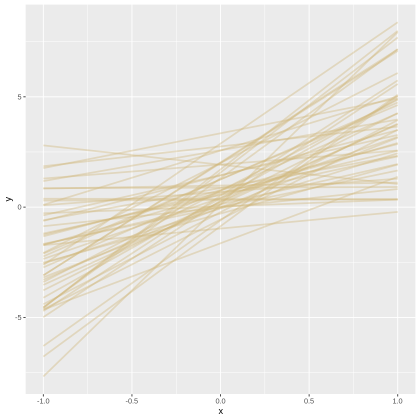

```python
gen_slopes()
gen_slopes(var = 3)
gen_slopes(var = 5)
gen_slopes(var = 10)
gen_slopes(var = 25)
```

The greater the variance in the data, the greater variance in the slopes of the lines of best fit. For the highest variance data, some of the lines of best fit even have a negative slope.

#### 2. (c) Distributions of Slopes

As we see above, the slopes are somewhat random. That means that they follow some sort of distribution, which we can try to discern. The code below computes `num_samples` independent realizations of the model data, computes the SLR model, and generates a histogram of the resulting slopes.

Again, experiment with different variances for the simulated data and record what you notice. What do you notice about the shapes of the resulting histograms?

```python
hist_slopes <- function(num.slopes=500, var=1, num.samples=20){
    slopes = rep(0, num.slopes)
    # For num.slopes, compute a SLR model slope
    for(i in 1:num.slopes){
        # Simulate the desired data
        data = sim_data(var=var, n=num.samples)
        # Fit an SLR model to the data
        lmod = lm(y~x, data=data)
        # Add the slopes to the vector of slopes
        slopes[i] = lmod$coef[2]
    }
    # Plot a histogram of the resulting slopes
    g = ggplot() + aes(slopes) + geom_histogram(color="black", fill="#CFB87C")
    return(g)
}
```

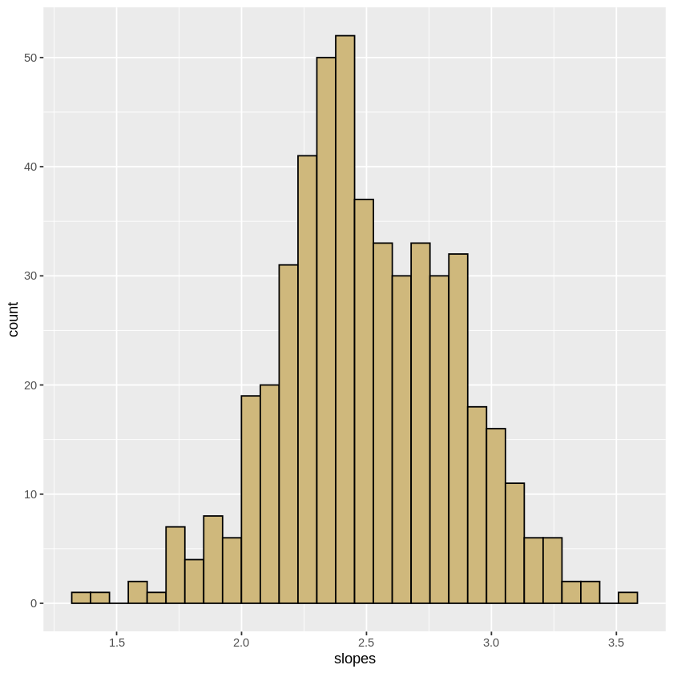

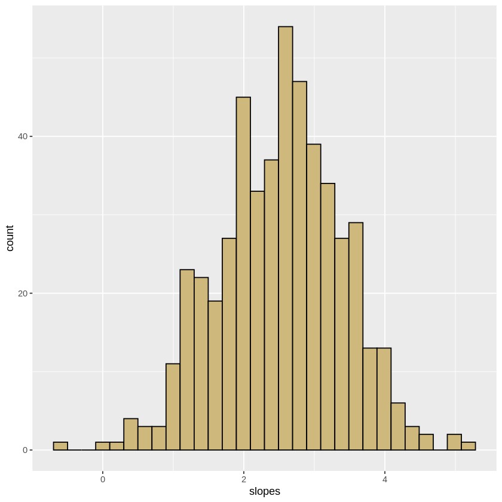

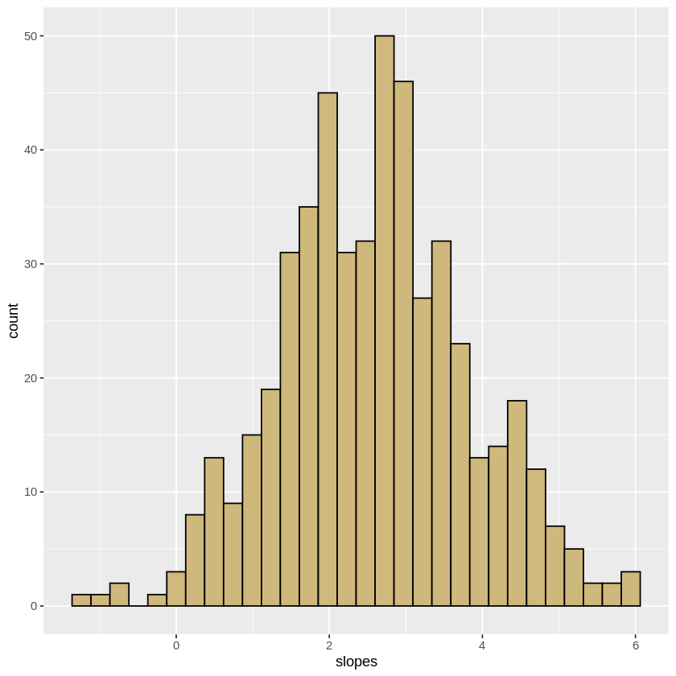

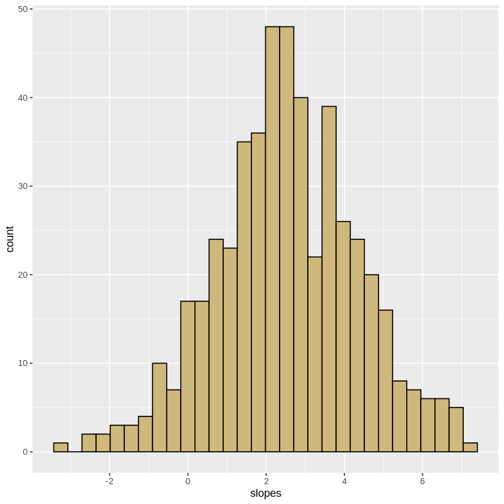

```python
hist_slopes()
hist_slopes(var = 5)
hist_slopes(var = 10)
hist_slopes(var = 25)
```

Regardless of how much the variance increases, the slopes always appear to be normally distributed around a slope of ~2.5 units. The range of slopes increases with variance but the mean of the slopes is unaffected.

#### 2. (d) Confidence Intervals of Slopes

What does that all mean? It means that when we fit a linear regression model, our parameter *estimates* will not be equal to the true parameters. Instead, the estimates will vary from sample to sample, and form a distribution. This is true for any linear regression model with any data - not just simulated data - as long as we assume that there is a large population that we can resample the response from (at fixed predictor values). Also note that we only demonstrated this fact with the slope estimate, but the same principle is true for the intercept, or if we had several slope parameters.

This simulation shows that there is a chance for a linear regression model to have a slope that is very different from the true slope. But with a large sample size, $n$, or small error variance, $\sigma^2$, the distribution will become narrower. Confidence intervals can help us understand this variability. The procedure that generates confidence intervals for our model parameters has a high probability of covering the true parameter. And, the higher $n$ is, for a fixed $\sigma^2$, or the smaller $\sigma^2$ is, for a fixed $n$, the narrower the confidence interval will be!

Draw a single sample of size $n=20$ from `sim_data()` with variance $\sigma^2 = 1$. Use your sample to compute a 95% confidence interval for the slope. Does the known slope for the model (which we can recall is $2.5$) fall inside your confidence interval? How does the value of $\sigma^2$ affect the CI width?

```python
new_sample <- sim_data(n=20, var=1)
sample_lm <- lm(y ~ x, data = new_sample)
summary(sample_lm)
slope_conf <- confint(sample_lm, level = 0.95)
slope_conf
```

```
Call:
lm(formula = y ~ x, data = new_sample)

Residuals:
    Min      1Q  Median      3Q     Max
-1.7357 -0.6542  0.2532  0.5524  1.2284

Coefficients:
            Estimate Std. Error t value Pr(>|t|)
(Intercept)   1.5141     0.1973   7.673 4.42e-07 ***
x             2.6290     0.3251   8.086 2.10e-07 ***
---
Signif. codes:  0 ‘***’ 0.001 ‘**’ 0.01 ‘*’ 0.05 ‘.’ 0.1 ‘ ’ 1

Residual standard error: 0.8825 on 18 degrees of freedom
Multiple R-squared:  0.7841,	Adjusted R-squared:  0.7722
F-statistic: 65.39 on 1 and 18 DF,  p-value: 2.102e-07
```

A matrix: 2 × 2 of type dbl

|  | 2.5 % | 97.5 % |
| --- | --- | --- |
| (Intercept) | 1.099524 | 1.928711 |
| x | 1.945994 | 3.312088 |